# Lab 2. Introduction to Geostatistics

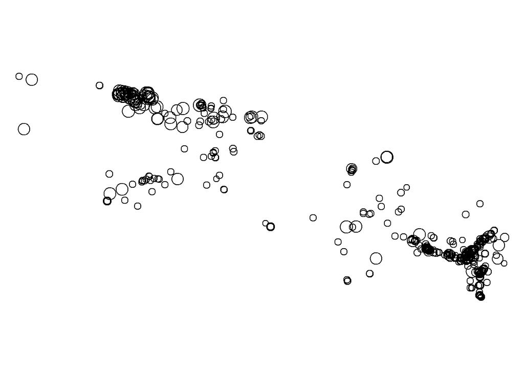

```r
## Create matrix of coordinates
sp_point <- matrix(NA, nrow=nrow(data),ncol=2)
sp_point[,1] <- jitter(data$LONG,.001)
sp_point[,2] <- jitter(data$LAT, .001)
colnames(sp_point) <- c("LONG","LAT")

## Create spatial object
## Projection: UTM zone 48
data.sp <- SpatialPointsDataFrame(coords=sp_point,data,proj4string=CRS("+proj=utm +zone=48 +datum=WGS84"))

## Explore
par(mar=rep(0,4))
plot(data.sp,pch=1,cex=log(data.sp$LOAD_LBS)/5)
```

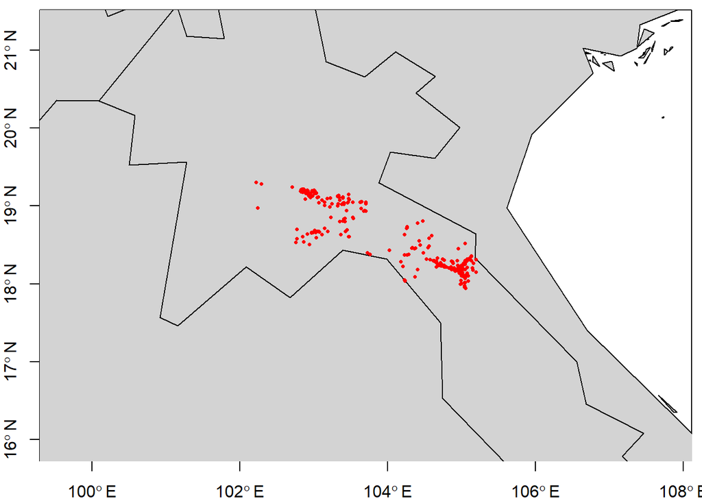

```r
## Zoom in on study region
par(mar=c(2,2,0.5,0.5))
plot(wrld_simpl,xlim=bbox(data.sp)[1,]+c(-1,1),ylim=bbox(data.sp)[2,]+c(-2,2),col="lightgrey",axes=T) ## World Map
plot(data.sp,pch=16,cex=.5,col="red",add=T)
```

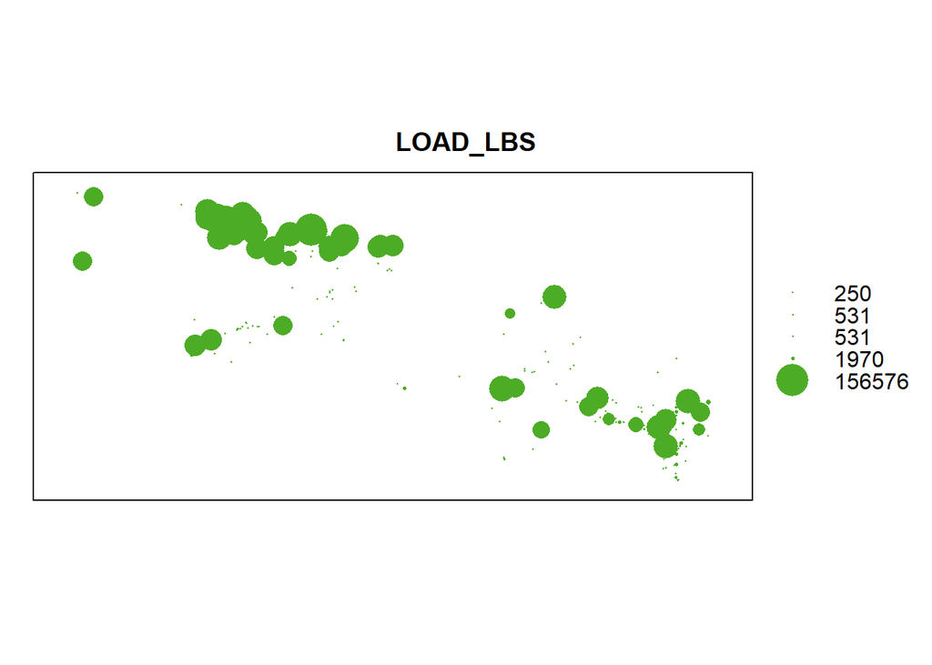

```r
## Take a look at the payload variable
bubble(data.sp,"LOAD_LBS")
```

# 2 Variogram

In geostatistics, spatial autocorrelation has traditionally been modeled by a $\bf{\text variogram}$, which describes the degree to which nearby locations have similar values.

Below is the variogram cloud for Laos bomb load (natural log).

- ${\bf Upper\ left\ corner}$: point pairs are close together, but have very different values.
- ${\bf Lower\ left\ corner}$: point pairs are close together, and have similar values.
- ${\bf Upper\ right\ corner}$: point pairs are far apart, and have different values.
- ${\bf Lower\ right\ corner}$: point pairs are far apart, but have similar values.

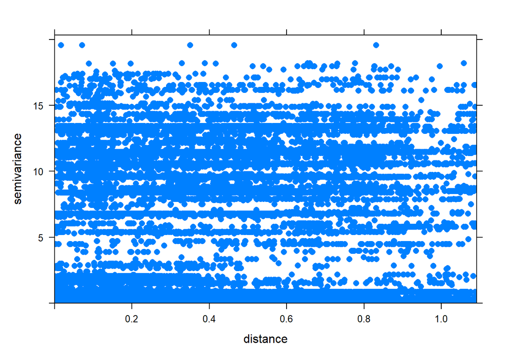

```r
## Variogram cloud
plot(variogram(log(LOAD_LBS)~1, locations=coordinates(sp_point), data=data.sp, cloud=T), pch=16, cex=1)
```

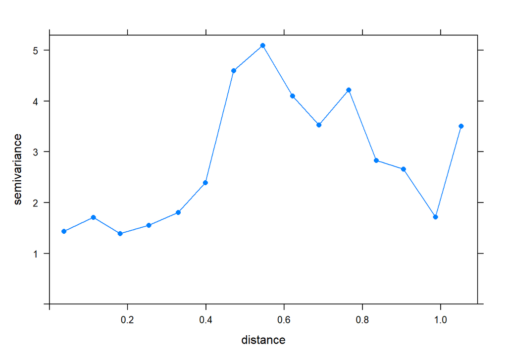

```r
## Sample variogram
plot(variogram(log(LOAD_LBS)~1, locations=coordinates(sp_point), data=data.sp, cloud=F), type="b", pch=16)
```

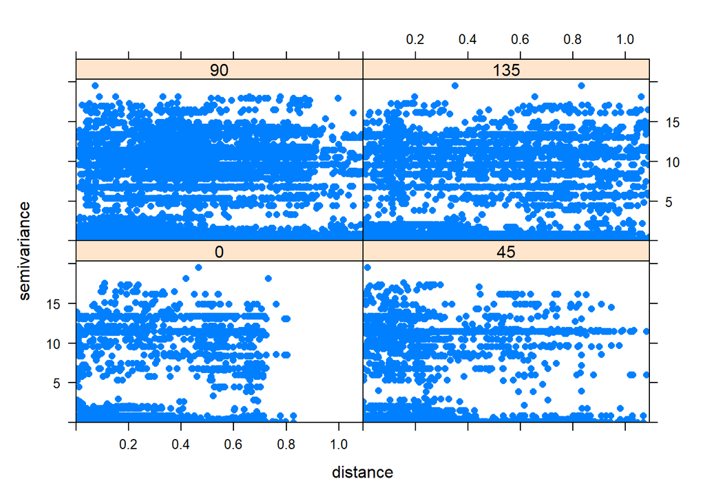

```r
## Directional search
plot(variogram(log(LOAD_LBS)~1, locations=coordinates(sp_point), data=data.sp, alpha=c(0,45,90,135),cloud=T), pch=16)
```

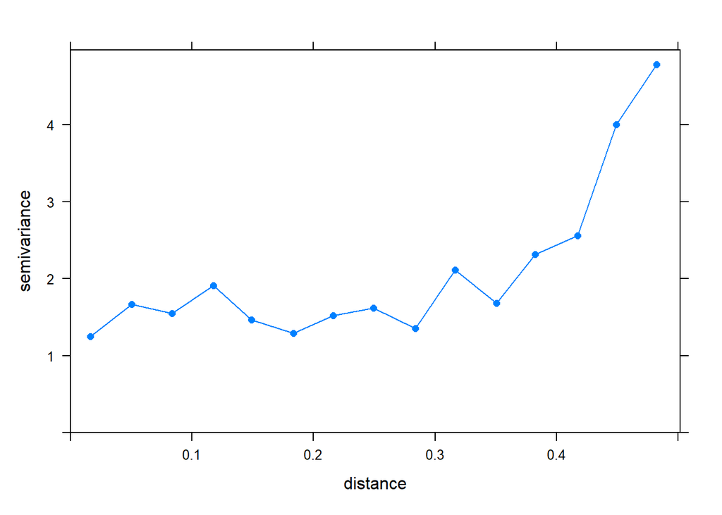

```r
## Modify cutoff
plot(variogram(log(LOAD_LBS)~1, locations=coordinates(sp_point), data=data.sp, cutoff=.5 ,cloud=F), type="b",  pch=16)
```

The variogram can be used for spatial prediction. This can be done by fitting a parametric model to the variogram.

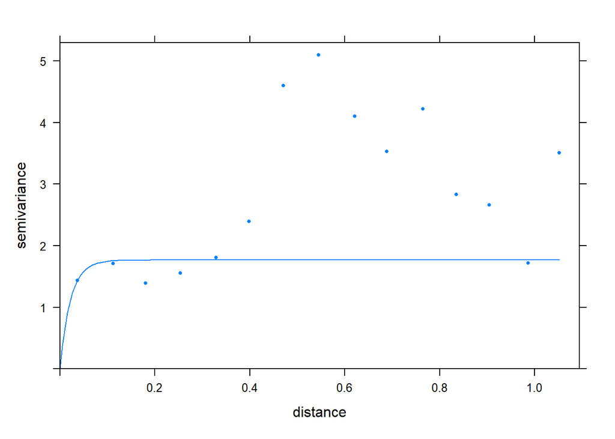

```r
## Fit variogram with exponential model
v <- variogram(log(LOAD_LBS) ~ 1, locations=coordinates(sp_point), data.sp)
v.fit <- fit.variogram(v, vgm(psill=1, model="Exp", range=1))
plot(v, v.fit, pch = 16, cex=.5)
```

# 3 Ordinary Kriging

Spatial interpolation is the prediction of values of attributes at unsampled locations $s_{0}$ from existing measurements at $s_{0}$. This procedure converts a sample of point observations into an alternative representation, such as a contour map or grid.

Kriging is used to interpolate a value $Z(s_{0})$ of a random field $Z(s)$ at unobserved location $s_{0}$, using data from observed location $s_{i}$. Allows variance to be non-constant, dependent on distance between points as modeled by the variogram $\gamma(d)$. The kriging estimator is given by $\hat{Z}(s_{0})=\sum_{i=1}^{n}w_{i}(s_{0})Z(s_{i})$ where $w_{i}(s_{0}), i=1,\dots,n$ is a spatial weight.

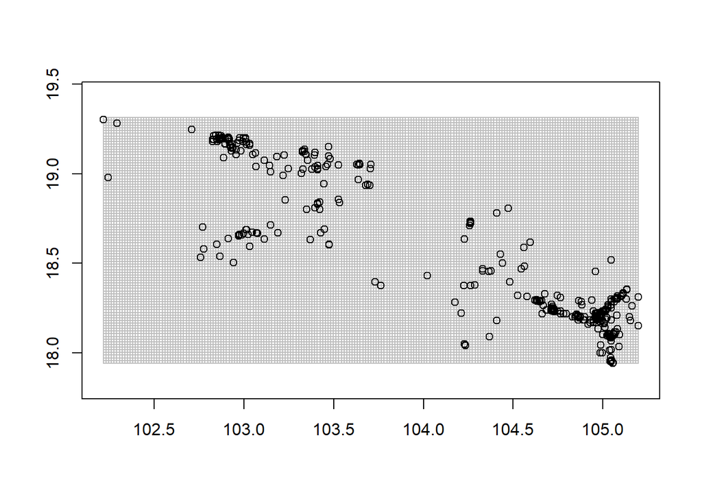

```r
## Create empty grid
grd <- Sobj_SpatialGrid(data.sp, maxDim=200)$SG
plot(grd, axes=T, col="grey")
points(data.sp)
```

Predicted values and variance for ordinary kriging is shown below for the Laos bombing data.

```r
## Generate predictions
kr <- krige(log(LOAD_LBS)~1, data.sp, grd, model=v.fit)
```

```
## [using ordinary kriging]
```

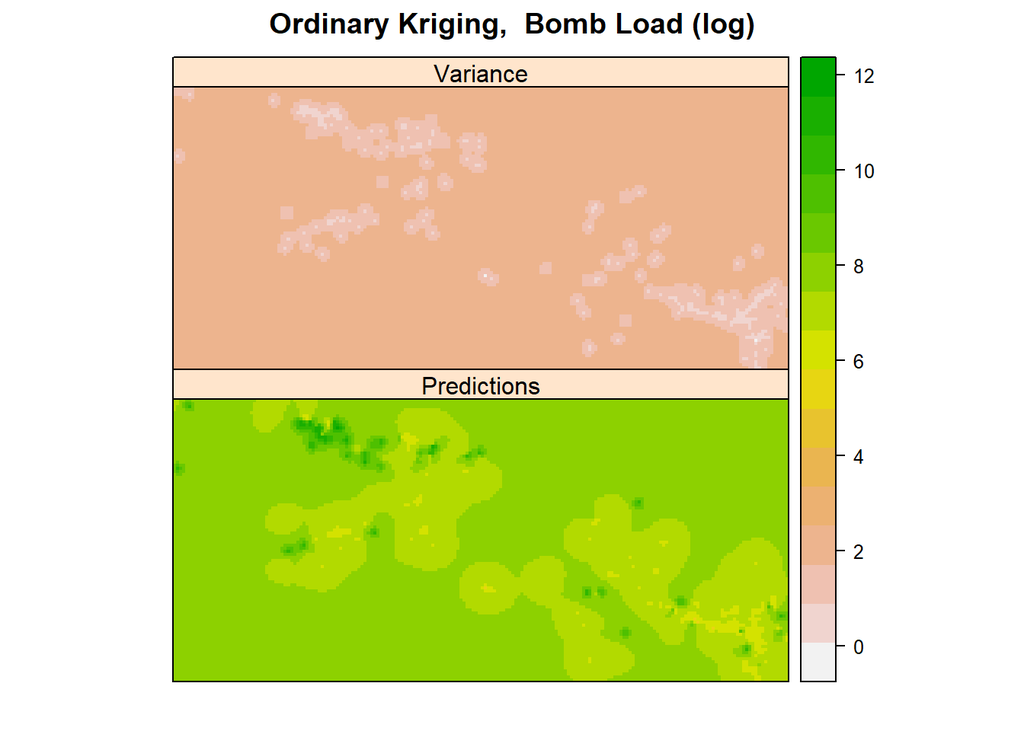

```r
spplot(kr, col.regions=rev(terrain.colors(100)), names.attr=c("Predictions","Variance"), main="Ordinary Kriging,  Bomb Load (log)", pch=2, cex=2)
```

# 4 IDW Interpolation

One approach to interpolation is to use a locally-weighted average of nearby values. Inverse-distance weighted (IDW) interpolation computes one such weighted average: $\hat{Z}(s_{0})=\sum_{i=1}^{n}w_{i0}Z(s_{1})$ where weights $w_{ij}$s are determined according to the distance between points $s_{i}$ and $s_{j}$, and scaled by parameter $k$, $w_{ij}=1/d_{ij}^{k}$.

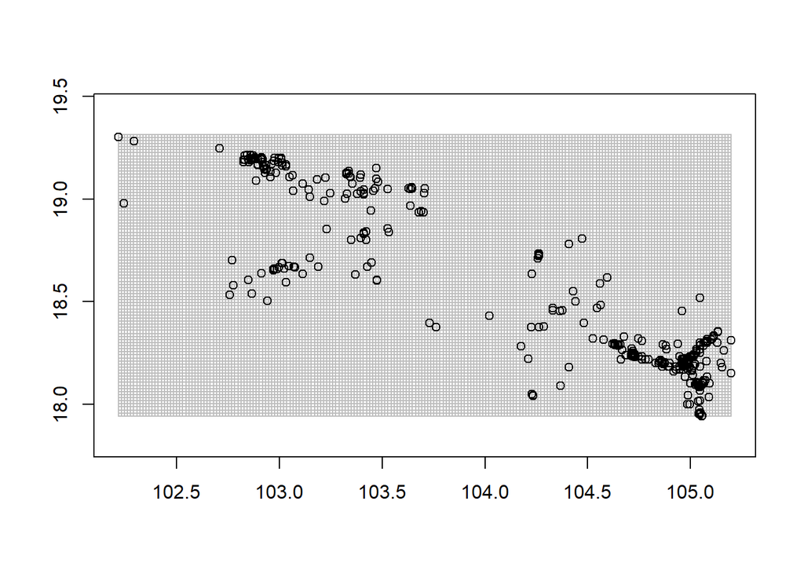

```r
## Create empty grid
grd <- Sobj_SpatialGrid(data.sp, maxDim=200)$SG
plot(grd, axes=T, col="grey")
points(data.sp)
```

```r
## Generate predictions

# k=.2
idw.out <- gstat::idw(log(LOAD_LBS)~1, data.sp, grd, idp=.2)
```

```
## [inverse distance weighted interpolation]
```

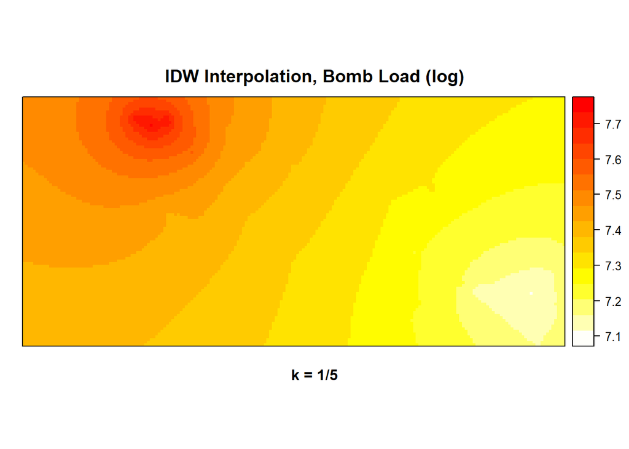

```r
spplot(idw.out[1], col.regions=rev(heat.colors(100)), main="IDW Interpolation, Bomb Load (log)", sub="k = 1/5")
```

```r
# k=1
idw.out <- gstat::idw(log(LOAD_LBS)~1, data.sp, grd, idp=1)
```

```
## [inverse distance weighted interpolation]
```

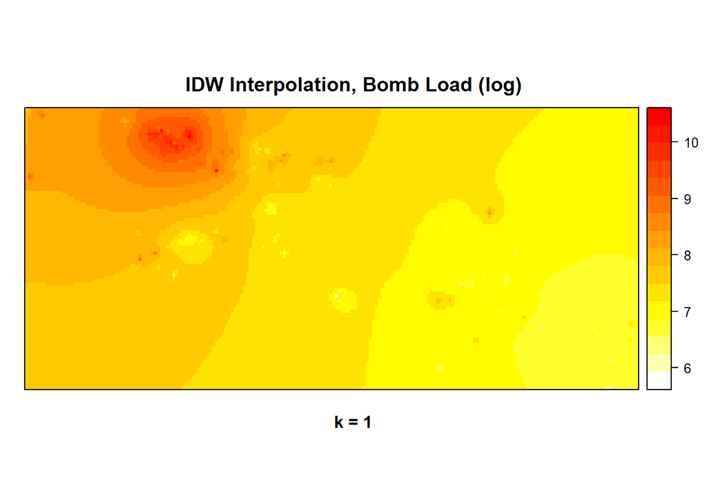

```r
spplot(idw.out[1], col.regions=rev(heat.colors(100)), main="IDW Interpolation, Bomb Load (log)", sub="k = 1")
```

```r
# k=5
idw.out <- gstat::idw(log(LOAD_LBS)~1, data.sp, grd, idp=5)
```

```
## [inverse distance weighted interpolation]
```

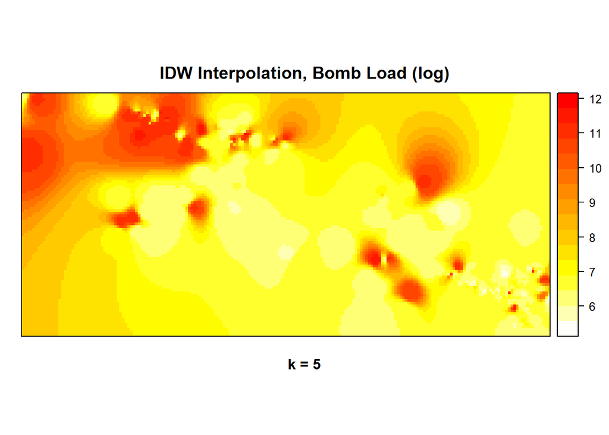

```r
spplot(idw.out[1], col.regions=rev(heat.colors(100)), main="IDW Interpolation, Bomb Load (log)",sub="k = 5")
```

## 4.1 Example of Texas precipitation data.

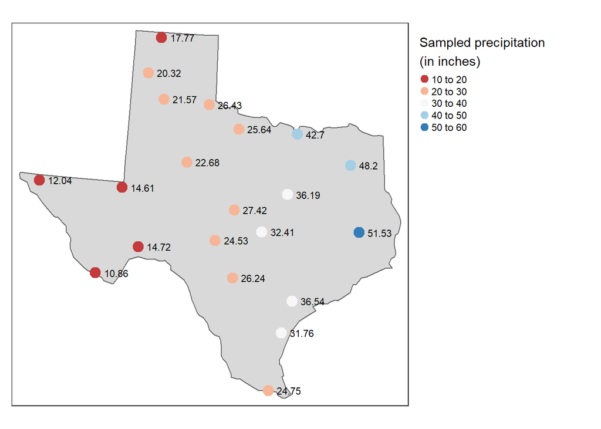

```r
#library(rgdal)
#library(tmap)
#library(raster)

# Load precipitation data
#z <- gzcon(url("http://colby.edu/~mgimond/Spatial/Data/precip.rds"))
#P <- readRDS(z)
P <- readRDS("../Dataset/precip.rds")

# Load Texas boudary map
#z <- gzcon(url("http://colby.edu/~mgimond/Spatial/Data/texas.rds"))
#W <- readRDS(z)
W <- readRDS("../Dataset/texas.rds")

# Replace point boundary extent with that of Texas
P@bbox <- W@bbox

tm_shape(W) + tm_polygons() +
  tm_shape(P) +
  tm_dots(col="Precip_in", palette="RdBu", auto.palette.mapping=FALSE,
             title="Sampled precipitation \n(in inches)", size=0.7) +
  tm_text("Precip_in", just="left", xmod=.5, size = 0.7) +
  tm_legend(legend.outside=TRUE)
```

The IDW output is a raster. This requires that we first create an empty raster grid, then interpolate the precipitation values to each unsampled grid cell.

```r
# Create an empty grid where n is the total number of cells
grd              <- as.data.frame(spsample(P, "regular", n=50000))
names(grd)       <- c("X", "Y")
coordinates(grd) <- c("X", "Y")
gridded(grd)     <- TRUE  # Create SpatialPixel object
fullgrid(grd)    <- TRUE  # Create SpatialGrid object

# Add P's projection information to the empty grid
proj4string(P) <- proj4string(P) # Temp fix until new proj env is adopted
proj4string(grd) <- proj4string(P)

# Interpolate the grid cells using a power value of 2 (idp=2.0)
P.idw <- gstat::idw(Precip_in ~ 1, P, newdata=grd, idp=2.0)
```

```
## [inverse distance weighted interpolation]
```

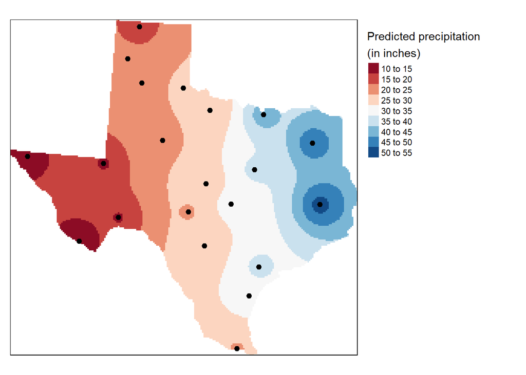

```r
# Convert to raster object then clip to Texas
r       <- raster(P.idw)
r.m     <- mask(r, W)

# Plot
tm_shape(r.m) +
  tm_raster(n=10, palette="RdBu", auto.palette.mapping=FALSE,
            title="Predicted precipitation \n(in inches)") +
  tm_shape(P) + tm_dots(size=0.2) +
  tm_legend(legend.outside=TRUE)
```